# index

Penny Cao

2/25/2022

## Introduction

The data set records incarceration at the county level and includes data on gender, race, age and other characteristics of the jail and prison population. Unlike traditional state-level data sets, this project is a more detailed analysis of local data, with the goal of helping county officials determine how communities can best use incarceration. The variable I focus on for this report is the population count for jails in the most recent year. The state that has the highest jail population is California while Georgia has the highest black jail population. The proportion of black population in the total jail population in 2018 is 33.5713775. When comparing the proportion of whites and blacks in the total jail population, the result is that whites population is 1.3979641 times of black population. A good news is that the change in total jail population from 2017 to 2018 is -3385.75, with the negative sign meaning a decline in the jail population.

## Trends Chart

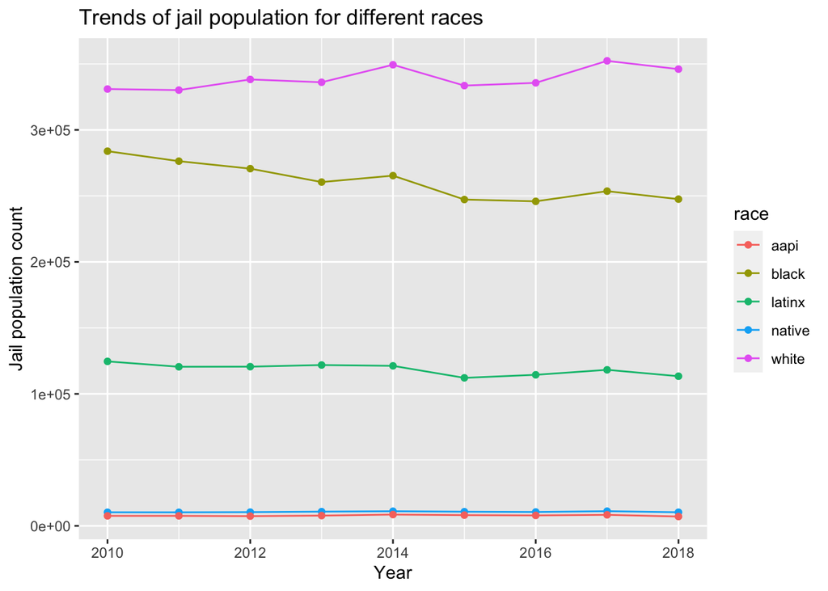

```r
trend_chart
```